# R Notebook

```r
rm(list=ls())
```

```r
library(interactions)
library(jtools)
library(MuMIn)
library(lme4)
library(cowplot)
library(ggplot2)
```

# Read in objects

```r
mot <- readRDS("../Data/05_melted.phyla.glom.rds")
```

```r
proteobacteria.df <- mot[mot$Phylum=="Proteobacteria",]
firmicutes.df <- mot[mot$Phylum=="Firmicutes",]
```

Split df by phyla and subset to adults

```r
proteobacteria.adult.df <- mot[(mot$Phylum=="Proteobacteria" & mot$ageBinned=="adult"),]
firmicutes.adult.df <- mot[(mot$Phylum=="Firmicutes" & mot$ageBinned=="adult"),]
```

Read in dredged objects

```r
model.set.proteo <- readRDS("../Data/dredgeSaves/model.set.proteo")
model.set.firmicutes <- readRDS("../Data/dredgeSaves/model.set.firmicutes")
model.set.proteo.adult <- readRDS("../Data/dredgeSaves/model.set.proteo.adult")
model.set.firmicutes.adult <- readRDS(file = "../Data/dredgeSaves/model.set.firmicutes.adult")
```

Create objects for non-model averaged models * seems to fit model when extracting it: glmer package and binomial response variable required

```r
binomial.response <- cbind(proteobacteria.df$Abundance/proteobacteria.df$NumberOfReads)
proteobacteria.model <- get.models(model.set.proteo, subset = 1)[[1]]

binomial.response <- cbind(firmicutes.df$Abundance/firmicutes.df$NumberOfReads)
firmicutes.model <- get.models(model.set.firmicutes, subset = 1)[[1]]
```

Adult top models

```r
binomial.response <- cbind(proteobacteria.adult.df$Abundance / proteobacteria.adult.df$NumberOfReads)
top.models.pro.adult <- get.models(model.set.proteo.adult, subset = delta<2)

binomial.response <- cbind(firmicutes.adult.df$Abundance / firmicutes.adult.df$NumberOfReads)
top.models.fir.adult <- get.models(model.set.firmicutes.adult, subset = delta<2)
```

Camille’s templates (for categorical plots)

```r
# NameOfYourPlotWithInteractions<-cat_plot(NameOfYourModel,pred=YourPredictorFromInteraction,modx=YourOtherPredictorFromInteraction,x.label="NAMEX", y.label="NAMEY
# ",interval =TRUE,int.type = "confidence", partial.residuals = TRUE)
#
# NameOfYourPlotWithOutInteractions<-effect_plot(NameOfYourModel,pred=YourPredictorOfInterest,x.label="Experimental Phase", y.label="Weighted
# Eigenvector Centrality",interval =TRUE,int.type = "confidence",partial.residuals = TRUE)
```

# All birds

## Age*habitat Not a model averaged result, only 1 model in top set

Getting error in weighted mean default * Solved by eliminating “data =” argument

[figure not shown]

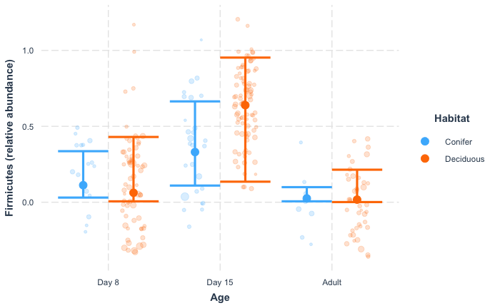

```r
#check.df <- proteobacteria.model@frame

firmicutes.model@frame$c.habitat <- ifelse(firmicutes.model@frame$c.habitat<0, "Conifer", "Deciduous")

ageXhabitat.firmic.all<-cat_plot(firmicutes.model, pred=ageBinned, modx=c.habitat, partial.residuals = TRUE, x.label="Age", y.label="Firmicutes (relative abundance)", legend.main = "Habitat", pred.labels = c("Day 8", "Day 15", "Adult"), interval =TRUE, int.type = "confidence", jitter = 0.4, point.alpha = 0.2, point.size = 0.75)# data = proteobacteria.model@frame)

ageXhabitat.firmic.all
```

## Distance

[figure not shown]

Re-read in these models because ifelse statement upstream, was upsetting the following plot codes

```r
binomial.response <- cbind(proteobacteria.df$Abundance/proteobacteria.df$NumberOfReads)
proteobacteria.model <- get.models(model.set.proteo, subset = 1)[[1]]

binomial.response <- cbind(firmicutes.df$Abundance/firmicutes.df$NumberOfReads)
firmicutes.model <- get.models(model.set.firmicutes, subset = 1)[[1]]
```

## Age*broodSize

Should i back-transform or “unstandardise” brood size for the plot? * can i just replace the standardised values in the model df with the actual values?

Error contrasts can be applied only to factors with 2 or more levels * but above plot is identical and still works? * can replace with proteobacteria model frame in hacky fix * seems to be getting upset with some code around age*habitat plot as skipping age habitat plot code allows this to be plotted from fresh start

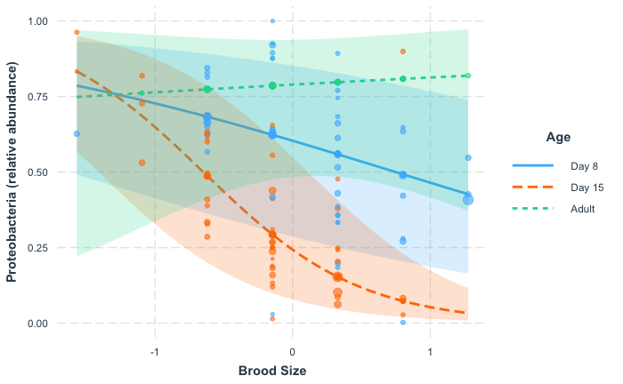

```r
#proteobacteria.model@frame$c.habitat <- ifelse(proteobacteria.model@frame$c.habitat<0, "conifer", "deciduous")

broodSizeXage.proteo.all<- interact_plot(proteobacteria.model, pred=z.broodSizeWhenSampled, modx=ageBinned, partial.residuals = TRUE, x.label="Brood Size", y.label="Proteobacteria (relative abundance)", interval =TRUE, int.type = "confidence", legend.main = "Age", modx.labels = c("Day 8", "Day 15", "Adult"), point.size = 0.75)

broodSizeXage.proteo.all
```

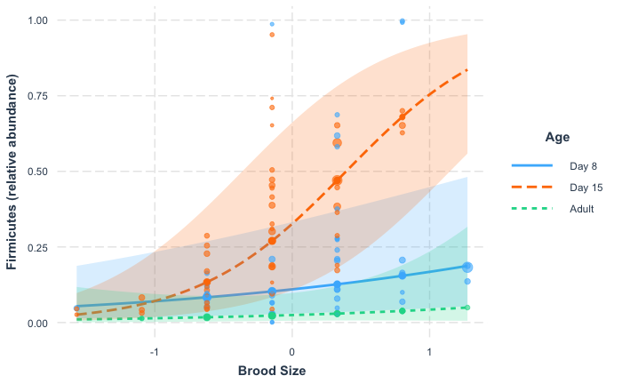

```r
# firmicutes.model.HACK <- firmicutes.model
# firmicutes.model.HACK@frame <- proteobacteria.model@frame

broodSizeXage.firmic.all <- interact_plot(firmicutes.model, pred=z.broodSizeWhenSampled, modx=ageBinned, partial.residuals = TRUE, x.label="Brood Size", y.label="Firmicutes (relative abundance)", interval =TRUE, int.type = "confidence", legend.main = "Age", modx.labels = c("Day 8", "Day 15", "Adult"), point.size = 0.75) # data = proteobacteria.model@frame)

broodSizeXage.firmic.all
```

## Age*Distance

```r
distanceXage.proteo.all <- interact_plot(proteobacteria.model, pred=z.DistanceToEdge, modx=ageBinned, partial.residuals = TRUE, x.label="Distance to edge", y.label="Proteobacteria (relative abundance)", interval =TRUE, int.type = "confidence", legend.main = "Age", modx.labels = c("Day 8", "Day 15", "Adult"), point.size = 0.75)
```

```
z.DistanceToEdge and ageBinned are not included in an interaction with one another in the
model.
```

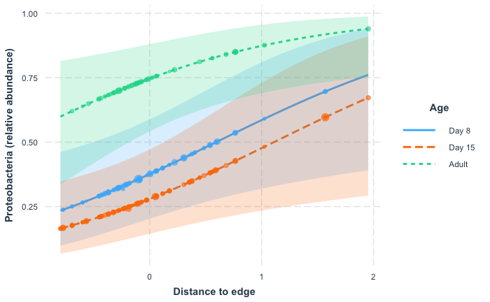

```r
distanceXage.proteo.all
```

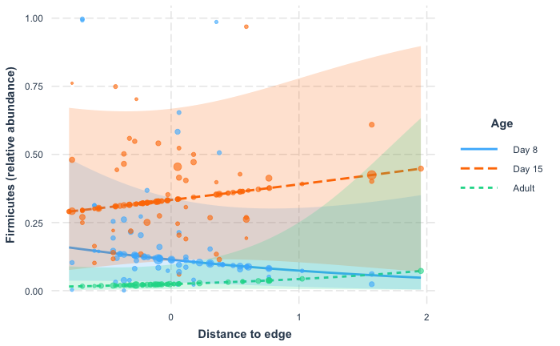

```r
distanceXage.firmic.all <- interact_plot(firmicutes.model, pred=z.DistanceToEdge, modx=ageBinned, partial.residuals = TRUE, x.label="Distance to edge", y.label="Firmicutes (relative abundance)", interval =TRUE, int.type = "confidence", legend.main = "Age", modx.labels = c("Day 8", "Day 15", "Adult"), point.size = 0.75)

distanceXage.firmic.all
```

## age*layDate

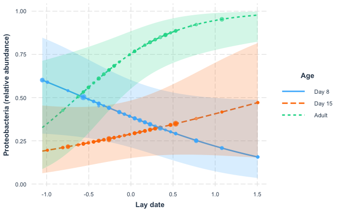

```r
layDatexage.proteo.all <- interact_plot(proteobacteria.model, pred=z.layDateFirst, modx=ageBinned, partial.residuals = TRUE, x.label="Lay date", y.label="Proteobacteria (relative abundance)", interval =TRUE, int.type = "confidence", legend.main = "Age", modx.labels = c("Day 8", "Day 15", "Adult"), point.size = 0.75)

layDatexage.proteo.all
```

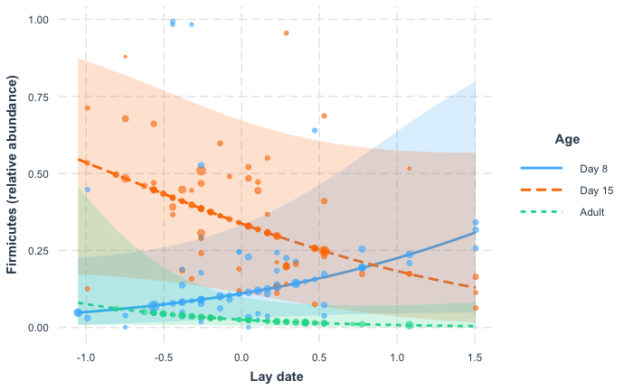

```r
layDateXage.firmic.all <- interact_plot(firmicutes.model, pred=z.layDateFirst, modx=ageBinned, partial.residuals = TRUE, x.label="Lay date", y.label="Firmicutes (relative abundance)", interval =TRUE, int.type = "confidence", legend.main = "Age", modx.labels = c("Day 8", "Day 15", "Adult"), point.size = 0.75)

layDateXage.firmic.all
```

# Adult birds

## Lay date

```r
#top.adult.proteo <- get.models(model.set.proteo.adult, subset = delta<2)
top.adult.proteo <- top.models.pro.adult[[1]]
#top.adult.proteo@frame$z.layDateFirst <- ifelse(top.adult.proteo@frame$c.ageDays>0,"Juvenile", "Mature")

layDate.proteo.adult<-effect_plot(top.adult.proteo, pred=z.layDateFirst, x.label="Lay date", y.label="Proteobacteria (relative abundance)", interval =TRUE, int.type = "confidence", partial.residuals = TRUE, jitter = 0.01, point.alpha = 0.2, point.size = 0.75) +ylim(0,1)
```

```
Confidence intervals for merMod models is an experimental feature. The intervals
reflect only the variance of the fixed effects, not the random effects.
```

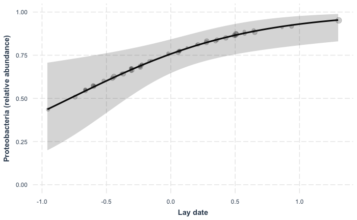

```r
layDate.proteo.adult
```

Automatically making y axis between 0, 0.2. I will force to 0,1 to make more comparable

[figure not shown]

# Arrange plots

```r
theme_classic2 <- function(base_size = 12, base_family = ""){
  theme_bw(base_size = base_size, base_family = base_family) %+replace%
    theme(
      legend.position = "none",
      panel.border     = element_blank(),
      axis.line        = element_line(colour = "black"),
      panel.grid.major=element_line(colour="grey", size=0.5, 3),
      panel.grid.major.x = element_blank(),
      panel.grid.major.y = element_blank(),
      panel.grid.minor = element_blank(),
      panel.grid.minor.x = element_blank(),
      panel.grid.minor.y = element_blank(),
      strip.background = element_blank(),
      legend.key       = element_blank(),
      plot.title = element_text(hjust = 0.5, face = "bold") # centre and bold title
    )
}
```

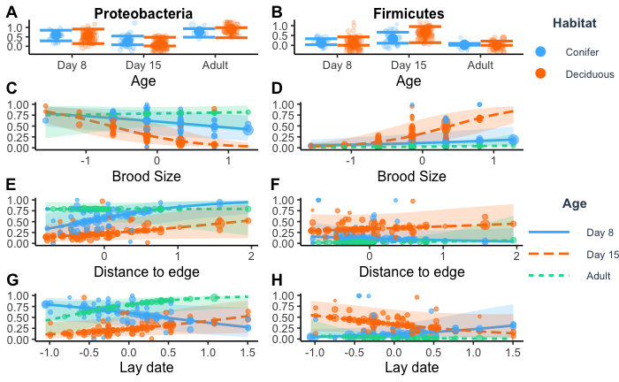

```r
p3 <- plot_grid(ageXhabitat.proteo.all+theme_classic2()+ylab(NULL)+labs(title="Proteobacteria"), ageXhabitat.firmic.all+theme_classic2()+ylab(NULL)+labs(title="Firmicutes"), ncol=2, labels = c("A", "B"))

p4 <- plot_grid(broodSizeXage.proteo.all+theme_classic2()+ylab(NULL), broodSizeXage.firmic.all+theme_classic2()+ylab(NULL), distanceXage.proteo.all+theme_classic2()+ylab(NULL), distanceXage.firmic.all+theme_classic2()+ylab(NULL), layDatexage.proteo.all+theme_classic2()+ylab(NULL), layDateXage.firmic.all+theme_classic2()+ylab(NULL), ncol=2, labels = c("C", "D", "E", "F", "G", "H"), label_x = 0, label_y = 1.2)

# get common legend of all interaction plots
p3.legend <- get_legend(ageXhabitat.proteo.all)
p4.legend <- get_legend(broodSizeXage.proteo.all)

p3.grid <- plot_grid(p3, p3.legend, rel_widths = c(3, .5))
p4.grid <- plot_grid(p4, p4.legend, rel_widths = c(3, .5))

p5 <- plot_grid(p3.grid, p4.grid, nrow = 2,  rel_heights = c(1,3))
p5
```

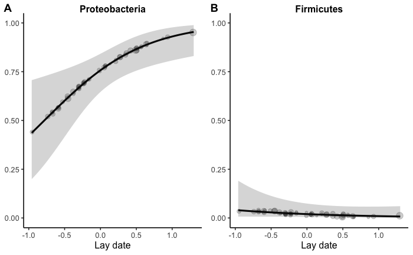

```r
p1 <- plot_grid(layDate.proteo.adult+theme_classic2()+ylab(NULL)+labs(title="Proteobacteria"), layDate.firmic.adult+theme_classic2()+ylab(NULL)+labs(title="Firmicutes"), labels = c("A", "B"))

p1
```

# Plot model averaged models

Error: $ operator is invalid for atomic vectorsxs

```r
# model.avg.proteobacteria.adult <- model.avg(top.models.pro.adult)
#
# interact_plot(model.avg.proteobacteria.adult, pred=z.layDateFirst, modx=c.Sex, interval =TRUE, int.type = "confidence", x.label="Lay date", y.label="Firmicutes (relative abundance)", legend.main = "Sex" , data = top.adult.proteo@frame)
```